# QC report

- study: Illumina methylation data
- author: Analyst
- date: 14 April, 2021

## Parameters used for QC

```
## $colour.code
## NULL
##
## $control.categories
## NULL
##
## $sex.outlier.sd
## [1] 3
##
## $meth.unmeth.outlier.sd
## [1] 3
##
## $control.means.outlier.sd
## [1] 5
##
## $detectionp.samples.threshold
## [1] 0.25
##
## $beadnum.samples.threshold
## [1] 0.2
##
## $detectionp.cpgs.threshold
## [1] 0.25
##
## $beadnum.cpgs.threshold
## [1] 0.2
##
## $snp.concordance.threshold
## [1] 0.9
##
## $sample.genotype.concordance.threshold
## [1] 0.9
##
## $detection.threshold
## [1] 0.01
##
## $bead.threshold
## [1] 3
##
## $sex.cutoff
## [1] -2
```

## Sex mismatches

To separate females and males, we use the difference of total median intensity for Y chromosome probes and X chromosome probes. This will give two distinct clusters of intensities. Females will be clustered on the left and males on the right. There are 25 sex detection outliers, and 0 sex detection mismatches.

| sample.name | predicted.sex | declared.sex | xy.diff | status |
| --- | --- | --- | --- | --- |
| TOE912452-BIS-v02_R04C01 | F | F | -2.7191709 | outlier |
| TOE358161-BIS-v01_R05C01 | F | F | -2.6866587 | outlier |
| TOE924783-BIS-v01_R05C01 | F | F | -2.6236660 | outlier |
| TOE761944-BIS-v01_R08C01 | F | F | -2.6014337 | outlier |
| TOE515368-BIS-v02_R05C01 | F | F | -2.5440686 | outlier |
| TOE987475-BIS-v01_R07C01 | F | F | -2.4700821 | outlier |
| TOE373115-BIS-v01_R08C01 | F | F | -2.4232242 | outlier |
| TOE259805-BIS-v01_R02C01 | F | F | -2.3170992 | outlier |
| TOE721376-BIS-v01_R08C01 | F | F | -2.1717466 | outlier |
| TOE354579-BIS-v01_R06C01 | M | M | -0.1362833 | outlier |
| TOE416709-BIS-v01_R03C01 | M | M | -0.0543986 | outlier |
| TOE361401-BIS-v01_R01C01 | M | M | -0.0429601 | outlier |
| TOE383549-BIS-v01_R08C01 | M | M | 1.1173082 | outlier |
| TOE540603-BIS-v01_R08C01 | M | M | 1.1185043 | outlier |
| TOE871220-BIS-v01_R03C01 | M | M | 1.1547233 | outlier |
| TOE827132-BIS-v01_R05C01 | M | M | 1.1598372 | outlier |
| TOE902653-BIS-v01_R04C01 | M | M | 1.1606274 | outlier |
| TOE415449-BIS-v01_R04C01 | M | M | 1.1900516 | outlier |
| TOE822740-BIS-v01_R04C01 | M | M | 1.2195457 | outlier |
| TOE933492-BIS-v01_R06C01 | M | M | 1.2446973 | outlier |
| TOE892602-BIS-v01_R08C01 | M | M | 1.2917448 | outlier |
| TOE635128-BIS-v01_R07C01 | M | M | 1.3371820 | outlier |
| TOE290163-BIS-v02_R05C01 | M | M | 1.3438506 | outlier |
| TOE169059-BIS-v01_R08C01 | M | M | 1.3572722 | outlier |
| TOE500379-BIS-v01_R05C01 | M | M | 1.4094568 | outlier |

This is a plot of the difference between median chromosome Y and chromosome X probe intensities (“XY diff”). Cutoff for sex detection was XY diff = -2. Mismatched samples are shown in red. The dashed lines represent 3 SD from the mean xy difference. Samples that fall in this interval are denoted as outliers.

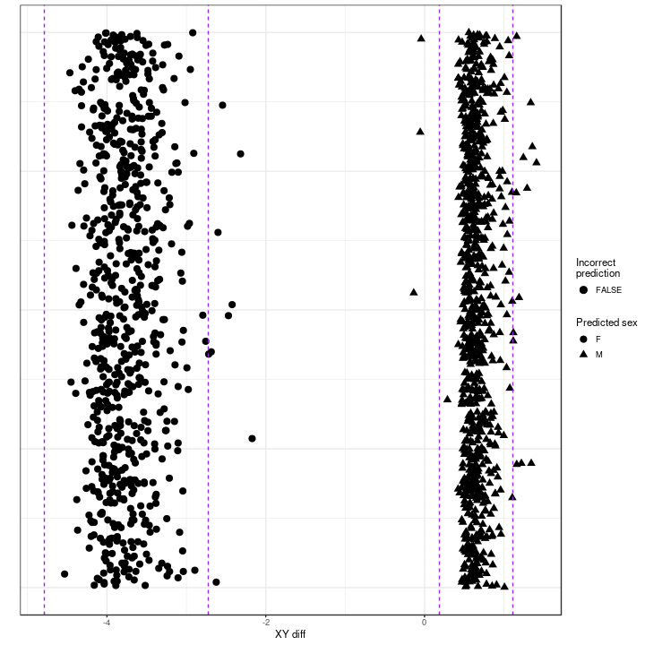

## Methylated vs unmethylated

To explore the quality of the samples, it is useful to plot the median methylation intensity against the median unmethylation intensity with the option to color outliers by group. There are 27 outliers from the meth vs unmeth comparison. Outliers are samples whose predicted median methylated signal is more than 3 standard deviations from the expected (regression line).

| sample.name | methylated | unmethylated | resids | methylated.lm | upper.lm | lower.lm | outliers |
| --- | --- | --- | --- | --- | --- | --- | --- |
| TOE259805-BIS-v01_R02C01 | 2601.023 | 1946.3472 | -981.9216 | 3582.944 | 4514.642 | 2651.247 | TRUE |
| TOE924783-BIS-v01_R05C01 | 2037.576 | 2480.6645 | -1347.5011 | 3385.077 | 4316.774 | 2453.379 | TRUE |
| TOE575830-BIS-v01_R02C01 | 1924.633 | 3906.4980 | -932.4316 | 2857.064 | 3788.762 | 1925.367 | TRUE |
| TOE701110-BIS-v01_R08C01 | 2657.598 | 965.7960 | -1288.4626 | 3946.061 | 4877.758 | 3014.363 | TRUE |
| TOE721376-BIS-v01_R08C01 | 1527.172 | 862.5192 | -2457.1343 | 3984.306 | 4916.004 | 3052.608 | TRUE |
| TOE383549-BIS-v01_R08C01 | 2452.438 | 1131.5124 | -1432.2552 | 3884.693 | 4816.390 | 2952.995 | TRUE |
| TOE415449-BIS-v01_R04C01 | 2087.195 | 2339.0188 | -1350.3358 | 3437.531 | 4369.228 | 2505.833 | TRUE |
| TOE869805-BIS-v01_R08C01 | 2714.995 | 1089.5666 | -1185.2305 | 3900.226 | 4831.924 | 2968.528 | TRUE |
| TOE497653-BIS-v01_R08C01 | 2614.989 | 1267.1383 | -1219.4786 | 3834.468 | 4766.166 | 2902.770 | TRUE |
| TOE807970-BIS-v01_R01C01 | 2001.015 | 3096.4418 | -1156.0285 | 3157.043 | 4088.741 | 2225.345 | TRUE |
| TOE354006-BIS-v01_R08C01 | 2838.838 | 1418.2851 | -939.6575 | 3778.496 | 4710.193 | 2846.798 | TRUE |
| TOE433638-BIS-v02_R07C01 | 1807.780 | 2206.2332 | -1678.9233 | 3486.704 | 4418.401 | 2555.006 | TRUE |
| TOE453175-BIS-v02_R05C01 | 1520.046 | 2809.6985 | -1743.1838 | 3263.229 | 4194.927 | 2331.532 | TRUE |
| TOE781222-BIS-v01_R08C01 | 2741.259 | 1516.1989 | -1000.9770 | 3742.236 | 4673.934 | 2810.539 | TRUE |
| TOE520586-BIS-v01_R04C01 | 1845.148 | 3984.6613 | -982.9714 | 2828.119 | 3759.817 | 1896.421 | TRUE |
| TOE646664-BIS-v01_R08C01 | 2105.085 | 2715.5306 | -1193.0166 | 3298.102 | 4229.799 | 2366.404 | TRUE |
| TOE285277-BIS-v01_R07C01 | 2675.020 | 1268.4706 | -1158.9542 | 3833.975 | 4765.672 | 2902.277 | TRUE |
| TOE178434-BIS-v02_R04C01 | 2129.711 | 2622.5605 | -1202.8187 | 3332.530 | 4264.228 | 2400.832 | TRUE |
| TOE635128-BIS-v01_R07C01 | 2341.899 | 1410.0094 | -1439.6611 | 3781.560 | 4713.258 | 2849.863 | TRUE |
| TOE515047-BIS-v01_R02C01 | 2612.118 | 1504.8588 | -1134.3173 | 3746.436 | 4678.133 | 2814.738 | TRUE |
| TOE414618-BIS-v01_R08C01 | 2412.733 | 2539.1293 | -950.6933 | 3363.426 | 4295.124 | 2431.729 | TRUE |
| TOE880818-BIS-v01_R05C01 | 2769.984 | 1573.1159 | -951.1746 | 3721.159 | 4652.856 | 2789.461 | TRUE |
| TOE467766-BIS-v01_R08C01 | 2459.240 | 1324.4672 | -1353.9984 | 3813.238 | 4744.936 | 2881.540 | TRUE |
| TOE728789-BIS-v01_R03C01 | 2168.812 | 1263.9569 | -1666.8337 | 3835.646 | 4767.344 | 2903.948 | TRUE |
| TOE146219-BIS-v01_R08C01 | 2736.606 | 1261.9037 | -1099.8001 | 3836.406 | 4768.104 | 2904.709 | TRUE |
| TOE324111-BIS-v01_R08C01 | 2982.382 | 1035.8565 | -937.7336 | 3920.116 | 4851.813 | 2988.418 | TRUE |
| TOE951516-BIS-v01_R05C01 | 2765.691 | 1287.8364 | -1061.1124 | 3826.803 | 4758.501 | 2895.105 | TRUE |

This is a plot of the methylation signals vs unmethylated signals

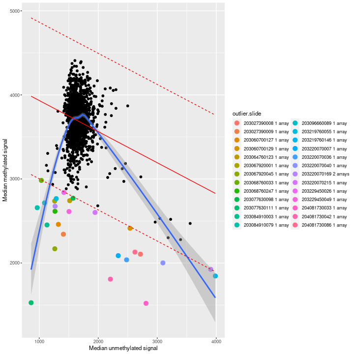

## Control probe means

There were 156 outliers detected based on deviations from mean values for control probes. The 450k array contains control probe which can be used to evaluate the quality of specific sample processing steps (staining, extension,target removal, hybridization, bisulfate conversion etc.). Control probes are grouped in 42 categories of control type. For each category a plot has been generated which shows the control means for each sample. Outliers are deviations from the mean. Some of the control probe categories have a very small number of probes. See Page 222 in this doc: https://support.illumina.com/content/dam/illumina-support/documents/documentation/chemistry_documentation/infinium_assays/infinium_hd_methylation/infinium-hd-methylation-guide-15019519-01.pdf. The most important control probes are the bisulfate1 and bisulfate2 control probes.

| sample.name | colour.code | id | variable | value | outliers |
| --- | --- | --- | --- | --- | --- |
| TOE538012-BIS-v01_R01C01 | 1 | 263 | bisulfite1 | 2703.0000000 | TRUE |
| TOE246058-BIS-v01_R01C01 | 1 | 583 | bisulfite1 | 2530.0000000 | TRUE |
| TOE122497-BIS-v01_R01C01 | 1 | 112 | bisulfite2 | 652.0000000 | TRUE |
| TOE538012-BIS-v01_R01C01 | 1 | 263 | bisulfite2 | 712.0000000 | TRUE |
| TOE730561-BIS-v01_R01C01 | 1 | 25 | extension.G.12719506 | 5170.0000000 | TRUE |
| TOE122497-BIS-v01_R01C01 | 1 | 112 | extension.G.12719506 | 6724.0000000 | TRUE |
| TOE538012-BIS-v01_R01C01 | 1 | 263 | extension.G.12719506 | 3301.0000000 | TRUE |
| TOE368936-BIS-v01_R01C01 | 1 | 327 | extension.G.12719506 | 6653.0000000 | TRUE |
| TOE246058-BIS-v01_R01C01 | 1 | 583 | extension.G.12719506 | 3130.0000000 | TRUE |
| TOE801427-BIS-v01_R02C01 | 1 | 590 | extension.G.12719506 | 5457.0000000 | TRUE |
| TOE622588-BIS-v01_R03C01 | 1 | 631 | extension.G.12719506 | 6854.0000000 | TRUE |
| TOE558157-BIS-v01_R02C01 | 1 | 655 | extension.G.12719506 | 5617.0000000 | TRUE |
| TOE613904-BIS-v01_R02C01 | 1 | 682 | extension.G.12719506 | 4506.0000000 | TRUE |
| TOE198427-BIS-v01_R01C01 | 1 | 945 | extension.G.12719506 | 4745.0000000 | TRUE |
| TOE415121-BIS-v01_R03C01 | 1 | 1405 | extension.G.12719506 | 6410.0000000 | TRUE |
| TOE730561-BIS-v01_R01C01 | 1 | 25 | extension.G.74666473 | 4036.0000000 | TRUE |
| TOE122497-BIS-v01_R01C01 | 1 | 112 | extension.G.74666473 | 5544.0000000 | TRUE |
| TOE538012-BIS-v01_R01C01 | 1 | 263 | extension.G.74666473 | 2495.0000000 | TRUE |
| TOE642486-BIS-v01_R02C01 | 1 | 316 | extension.G.74666473 | 6612.0000000 | TRUE |
| TOE368936-BIS-v01_R01C01 | 1 | 327 | extension.G.74666473 | 7517.0000000 | TRUE |
| TOE246058-BIS-v01_R01C01 | 1 | 583 | extension.G.74666473 | 2348.0000000 | TRUE |
| TOE801427-BIS-v01_R02C01 | 1 | 590 | extension.G.74666473 | 4495.0000000 | TRUE |
| TOE622588-BIS-v01_R03C01 | 1 | 631 | extension.G.74666473 | 6934.0000000 | TRUE |
| TOE558157-BIS-v01_R02C01 | 1 | 655 | extension.G.74666473 | 4940.0000000 | TRUE |
| TOE613904-BIS-v01_R02C01 | 1 | 682 | extension.G.74666473 | 4180.0000000 | TRUE |
| TOE495615-BIS-v02_R02C01 | 1 | 882 | extension.G.74666473 | 7753.0000000 | TRUE |
| TOE198427-BIS-v01_R01C01 | 1 | 945 | extension.G.74666473 | 6644.0000000 | TRUE |
| TOE415121-BIS-v01_R03C01 | 1 | 1405 | extension.G.74666473 | 6555.0000000 | TRUE |
| TOE730561-BIS-v01_R01C01 | 1 | 25 | extension.R.21752326 | 3328.0000000 | TRUE |
| TOE122497-BIS-v01_R01C01 | 1 | 112 | extension.R.21752326 | 2029.0000000 | TRUE |

[output cut: 126 more lines]

The distribution of sample control means are plotted here:

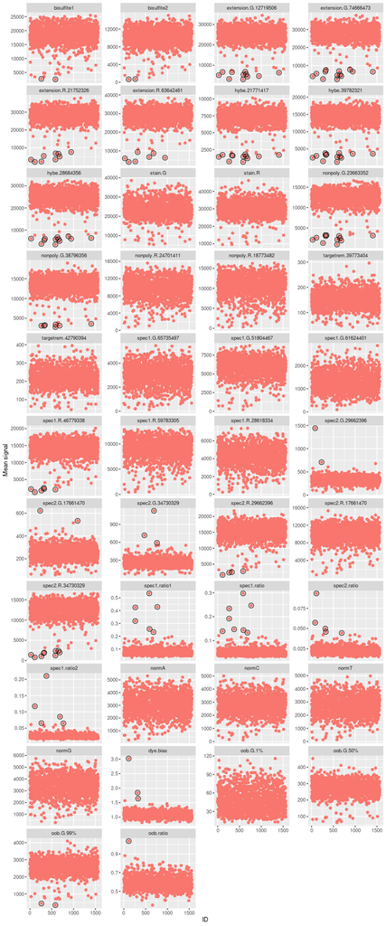

## Sample detection p-values

To further explore the quality of each sample the proportion of probes that didn't pass the detection pvalue has been calculated. There were 0 samples with a high proportion of undetected probes (proportion of probes with detection p-value > 0.01 is > 0.25).

Distribution:

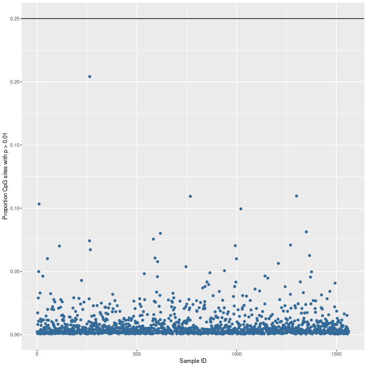

## Sample bead numbers

To further assess the quality of each sample the proportion of probes that didn't pass the number of beads threshold has been calculated. There were 0 samples with a high proportion of probes with low bead number (proportion of probes with bead number < 3 is > 0.2).

Distribution:

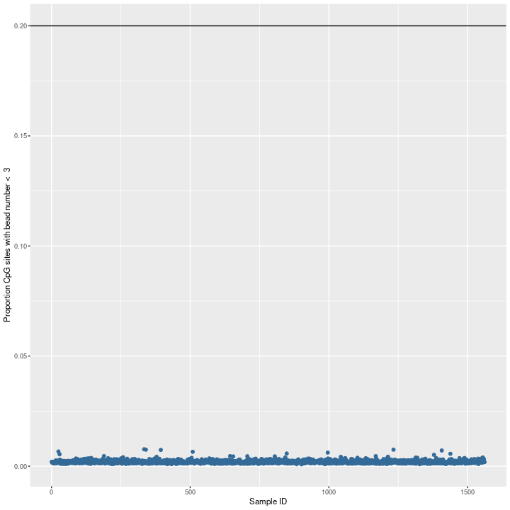

## CpG detection p-values

To explore the quality of the probes, the proportion of samples that didn't pass the detection pvalue threshold has been calculated. There were 5649 probes with only background signal in a high proportion of samples (proportion of samples with detection p-value > 0.01 is > 0.25). Manhattan plot shows the proportion of samples.

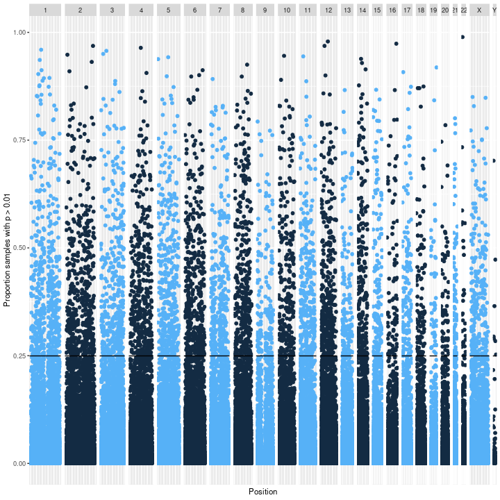

## Low number of beads per CpG

To further explore the quality of the probes, the proportion of samples that didn't pass the number of beads threshold has been calculated. There were 56 CpGs with low bead numbers in a high proportion of samples (proportion of samples with bead number < 3 is > 0.2). Manhattan plot of proportion of samples.

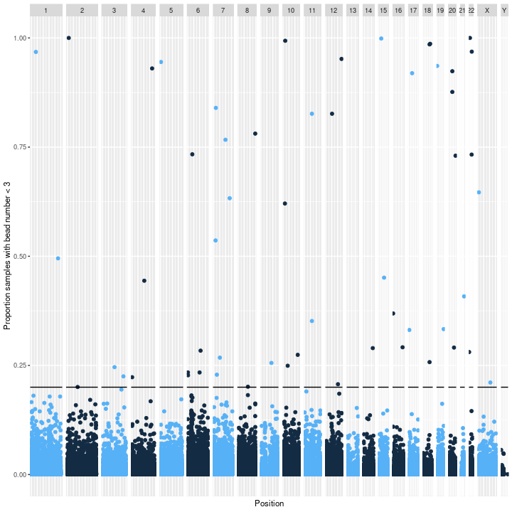

## Cellular composition estimates

Cell counts were estimated using the blood gse35069 complete cell type methylation profile references.

Plot compares methylation levels of CpG sites used to estimate cellular composition for each sample and reference methylation profile. Methylation levels of samples should generally overlap with reference methylation levels otherwise estimation will have simply selected the cell type reference with the nearest mean methylation level.

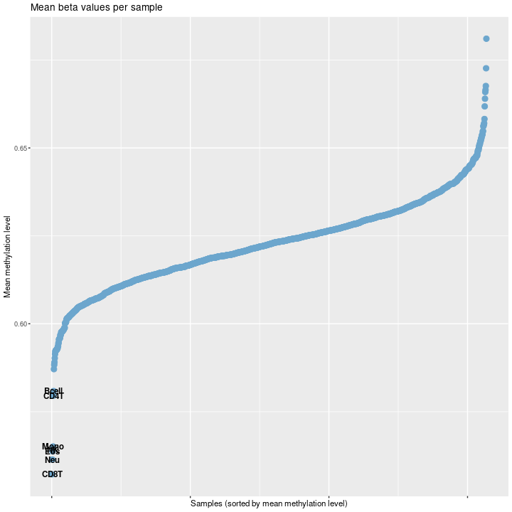

Boxplot shows the distributions of estimated cellular composition for each reference cell type across all samples.

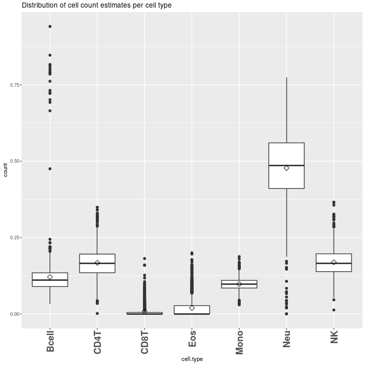

## SNP probe beta values

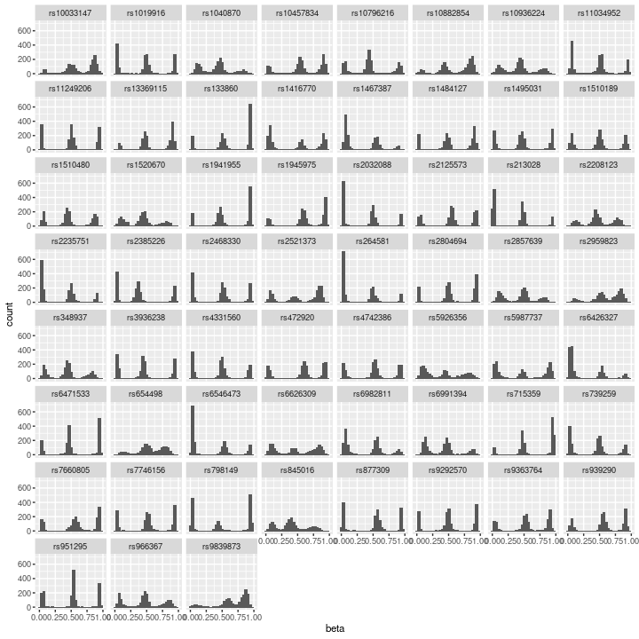

## Genotype concordance

This section omitted.